# 데이터 과학을 위한 R 알고리즘

수식에서 그래프까지

이광춘

[Tidyverse Korea](https://www.facebook.com/groups/tidyverse/)

2021-01-17

# 1 수식 편집기[^1]

기본적으로 $\LaTeX$ 작성은 [overleaf](https://www.overleaf.com/) 웹사이트에서 수식을 작성하고 공유한다. 정규분포 등 많은 수식은 https://equplus.net/ 웹사이트에서 이미 $\LaTeX$ 코드로 작성되어 있어 다운로드 받을 수 있다.

# 2 `ggplot` 수식 표기법 [1]

[7.2 Using Mathematical Expressions in Annotations](https://r-graphics.org/recipe-annotate-text-math)을 참조하면 `ggplot`에 수식을 넣을 수 있다. 방법은 `plotmath`을 사용하는 것인데, [Mathematical Annotation in R](https://astrostatistics.psu.edu/su07/R/html/grDevices/html/plotmath.html)을 참조한다.

`ggplot2` 팩키지에 `expression()` 함수를 사용해서 `plotmath` 그래픽 수식 표기를 수월하게 진행할 수 있다.

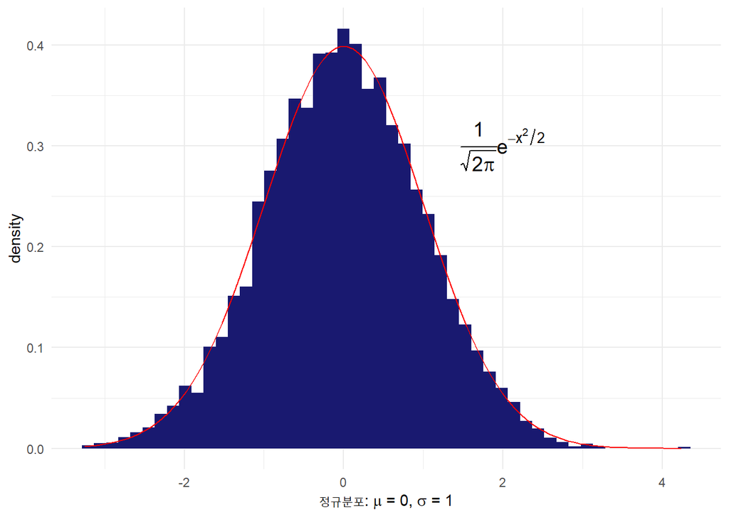

```r
library(tidyverse)

normal_tbl <- tibble(normal_var = rnorm(10000, mean = 0, sd = 1))

normal_tbl %>%
  ggplot(aes(normal_var)) +
    geom_histogram(aes(y=..density..), bins = 50, fill ="midnightblue") +
    # geom_density() +
    stat_function(data = normal_tbl,
                  fun = dnorm,
                  args = list(mean = 0, sd = 1), color = "red") +
    # labs(x = expression(glue::glue("{mu} = 0, {sigma} =1"))) +
    labs(x = expression(paste("정규분포: ", mu, " = 0, ", sigma, " = 1"))) +
    annotate("text", x = 2, y = 0.3, parse = TRUE, size = 5,
             label = "frac(1, sqrt(2 * pi)) * e ^ {-x^2 / 2}") +
    theme_minimal()
```

## 2.1 흔한 `ggplot` 그래프 [2]

`ggplot` 그래프에 수식과 관련된 정보를 함께 표현할 경우 문자열(String), 수학 표기법, 변수 등 다양한 요소가 한번에 필요한 경우가 있다.

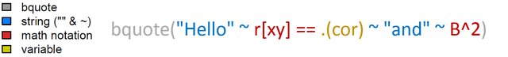

$\mu$와 $\sigma$ 수식 표기 뿐만 아니라 변수에 넣은 값도 함께 `bquote()`함수를 사용해서 `ggplot` 시각화를 할 수 있다.

`bquote("표준정규분포: " ~ mu == .(mu_val) ~ "그리고" ~ sigma^2 == .(sigma_val)))`

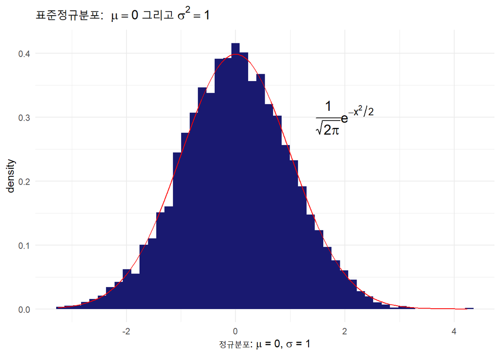

```r
mu_val    <- 0
sigma_val <- 1

normal_tbl %>%
  ggplot(aes(normal_var)) +
    geom_histogram(aes(y=..density..), bins = 50, fill ="midnightblue") +
    stat_function(data = normal_tbl,
                  fun = dnorm,
                  args = list(mean = 0, sd = 1), color = "red") +
    # labs(x = expression(glue::glue("{mu} = 0, {sigma} =1"))) +
    labs(x = expression(paste("정규분포: ", mu, " = 0, ", sigma, " = 1")),
         title = bquote("표준정규분포: " ~ mu == .(mu_val) ~ "그리고" ~ sigma^2 == .(sigma_val))) +
    annotate("text", x = 2, y = 0.3, parse = TRUE, size = 5,
             label = "frac(1, sqrt(2 * pi)) * e ^ {-x^2 / 2}") +
    theme_minimal()
```

## 2.2 $\LaTeX$ → R 그래프 수식

수식을 $\LaTeX$으로 표현하면 이를 `latex2exp` 팩키지를 사용해서 곧장 `ggplot` 시각화에 사용할 수도 있다. `latex2exp`는 $\LaTeX$ 문자열을 `plotmath` 표현식으로 변환하는 역할을 한다.

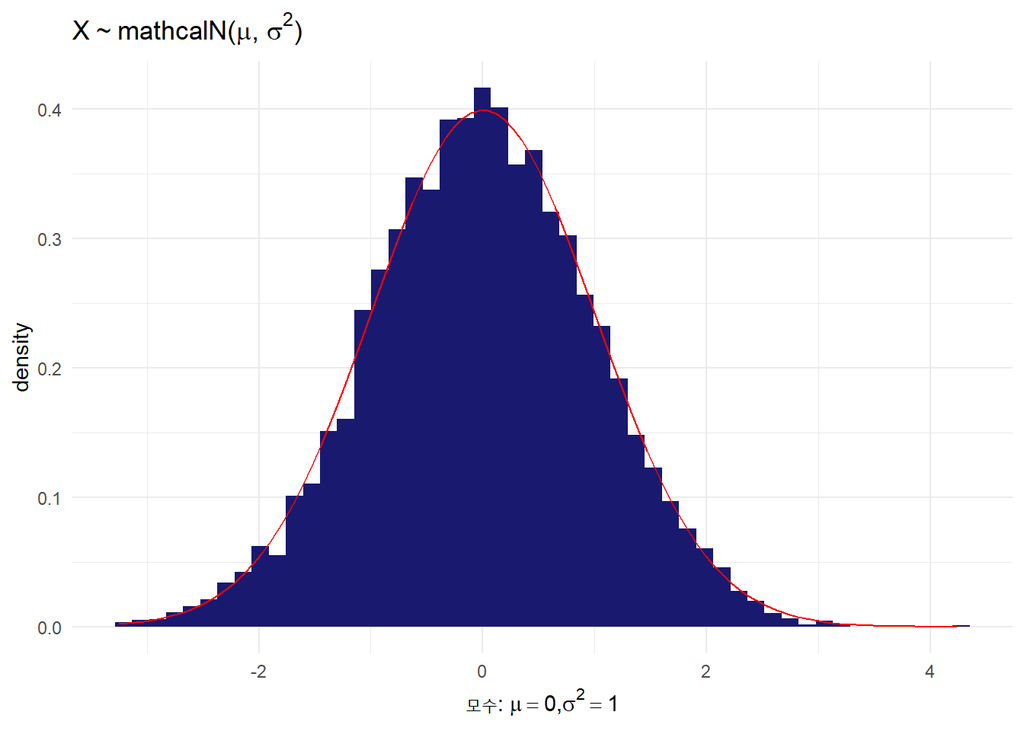

```r
library(latex2exp)
library(Hmisc)

normal_tbl %>%
  ggplot(aes(normal_var)) +
    geom_histogram(aes(y=..density..), bins = 50, fill ="midnightblue") +
    stat_function(data = normal_tbl,
                  fun = dnorm,
                  args = list(mean = 0, sd = 1), color = "red") +
    labs(x     = TeX("모수: $\\mu = 0, \\sigma^2 = 1 "),
         title = TeX("$X \\sim \\mathcal{N}(\\mu,\\,\\sigma^{2})$"))+
    theme_minimal()
```

일부 $\LaTeX$ 코드만 변환이 가능해서 아래 $\LaTeX$ 코드가 모두 변환이 된 것이 아니다. `latex2exp_supported()` 사용하면 적용가능한 $\LaTeX$ 기호를 확인하고 사용한다.

$X \sim \mathcal{N}(\mu,\,\sigma^{2})$

```r
latex2exp_supported()
```

```
 [1] "\\%"           "\\,"           "\\;"           "\\aleph"
 [5] "\\approx"      "\\ast"         "\\bar"         "\\bigcap"
 [9] "\\bigcup"      "\\bullet"      "\\cdot"        "\\cdots"
[13] "\\clubsuit"    "\\cong"        "\\degree"      "\\diamondsuit"
[17] "\\div"         "\\dot"         "\\equiv"       "\\exists"
[21] "\\forall"      "\\frac"        "\\geq"         "\\hat"
[25] "\\heartsuit"   "\\Im"          "\\in"          "\\infty"
[29] "\\int"         "\\LaTeX"       "\\lbrack"      "\\ldots"
[33] "\\leftarrow"   "\\Leftarrow"   "\\leq"         "\\lim"
[37] "\\mathbf"      "\\mathit"      "\\mathrm"      "\\neg"
[41] "\\neq"         "\\normalsize"  "\\notin"       "\\nsubset"
[45] "\\oplus"       "\\oslash"      "\\otimes"      "\\overset"
[49] "\\partial"     "\\perp"        "\\pm"          "\\prime"
[53] "\\prod"        "\\propto"      "\\rbrack"      "\\Re"
[57] "\\rightarrow"  "\\Rightarrow"  "\\sim"         "\\small"
[61] "\\spadesuit"   "\\sqrt"        "\\subset"      "\\subseteq"
[65] "\\sum"         "\\supset"      "\\supseteq"    "\\surd"
[69] "\\TeX"         "\\textbf"      "\\textit"      "\\tilde"
[73] "\\times"       "\\tiny"        "\\underline"   "\\vee"
[77] "\\wedge"       "\\widehat"     "\\widetilde"   "\\wp"
```

# 3 컴퓨터 대수학[^2]

- [심파이(Sympy)](https://www.sympy.org/)
  - [Sympy Online Shell](https://live.sympy.org/)
  - [기호 수학(Symbolic Math)](https://statkclee.github.io/symbolic-math/)
  - [R 팩키지: `caracas`](https://cran.r-project.org/web/packages/caracas/index.html)
- [`yacas`](http://yacas.org/)
  - [R 팩키지: `Ryacas`](https://mikl.dk/post/2019-ryacas-v100/)

$\lambda \exp(-\lambda x)$

1. Chang W. R graphics cookbook: Practical recipes for visualizing data. " O’Reilly Media, Inc."; 2012.

2. Rinker T. Math notation for r plot titles: Expression, bquote, & greek letters. 2018. https://trinkerrstuff.wordpress.com/2018/03/15/2246/.

[^1]: [EquPlus: database of equations - TEX/Latex/MathType/MathML codes](https://equplus.net/)
[^2]: [SymPy vs. Yacas](https://github.com/sympy/sympy/wiki/SymPy-vs.-Yacas)

데이터 과학자 [이광춘](https://github.com/statkclee/) 저작

*kwangchun.lee.7@gmail.com*